# Hezkuntzaren Lau Zutabetatik hasita 🗨️

Juan Abasolo

Zertara dator konpetentzia, edo lehen esaten izan den moduan: *gaitasuna*, omen diren horren inguruko diskurtso, ikusmolde eta pedagogia “berri” guzti hori?

Lau zutabeetatik hona

# Hasteko:

Munduari begira

Historiari

Konpetentziei

## Munduari begiratu eta …

Tentsioak

Erantzun eske dabilen gizartea

Hezkuntzan…

Zertara datorren

## Erantzun nahirik [`historia`]

Zelan etorri den

## Delors txostena, altxorrak eta zutabeak

**ikasten ikastea**

lifelong learning; dimentsio anitzeko hezkuntza

**egiten ikastea**

jakintza aplikatua, jendartean ekiteko

**elkarrekin bizitzen ikastea**

lankidetzarako eta gatazkak konpontzeko gaitasunak…

**izaten jakitea**

balioak, jarrerak

## Konpetentziak

zer diote direla?

zein diote garatu behar dela?

nork zer dio 🤔?

Erantzuna: gaitasunak konpetentziak

### DeSeCo [*](https://www.oecd.org/education/skills-beyond-school/definitionandselectionofcompetenciesdeseco.htm) ’02

### Euskal Curriculuma [*](https://euskalcurriculuma.eus/) ’05

### Europako kontseilua ’06

### Hezkuntza eredu pedagogikoaren markoa [*](https://www.euskadi.eus/oinarrizko-konpetentzia/web01-a3hbhezi/eu/) ’20

## Ariketa

**Konpetentzien ikuskerak**

Sortu taula bat konpetentzien definizioen alderaketa aztertzeko:

- Europako kontseilua
- Madrileko legeak
- Parisekoak
- Gasteizkoak
- Iruñekoak
- Ez Espainia - Ez Frantziak agintzen duten nonbaitekoak

# Communicative competence… & co.

## Ideiaren garapena

- Celce-Murcia
- Canale eta Swain
- EEBM
- …

## Celce & Murcia (1995)

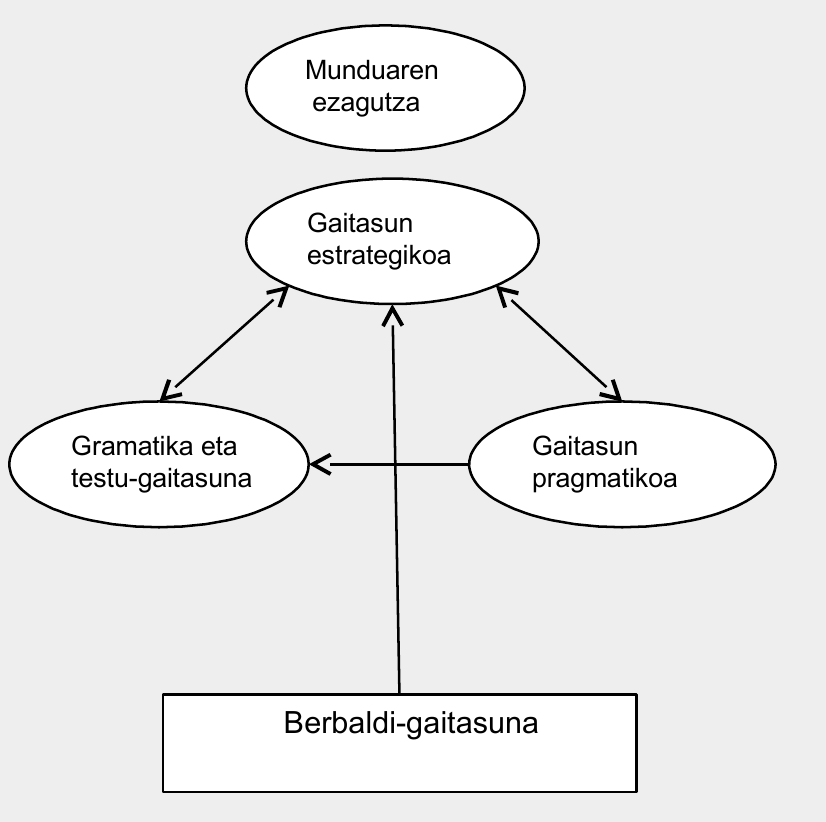

Definizioa

## Canale & Swain (1981)

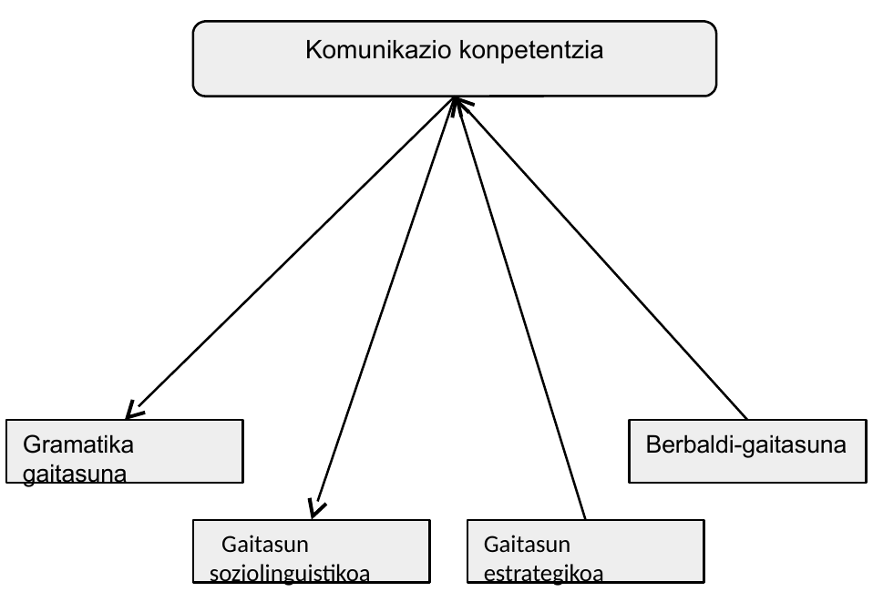

Definizioak

## EEMB (#23)

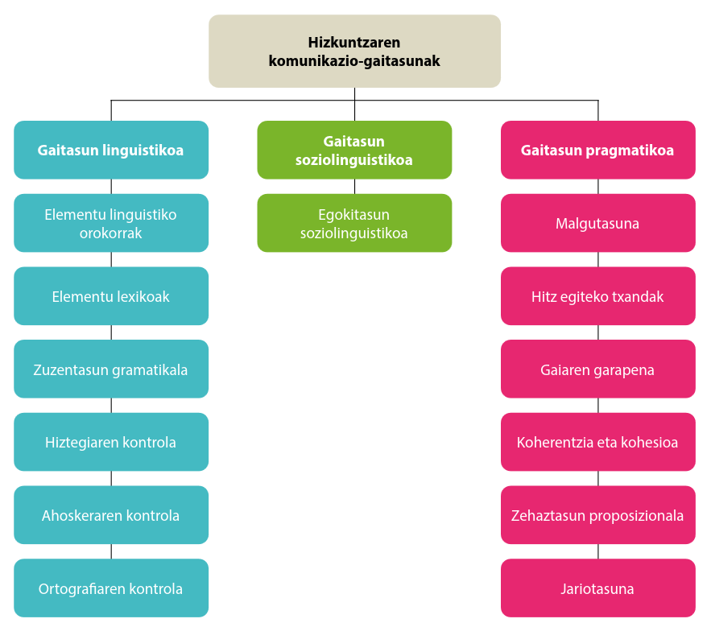

131.orritik aurrera definizioak-eta

## Ariketa

**Gurean zelan ikusten da?**

Lehenengo eguneko ariketako lanketa kontuan hartuta, irudikatu zelan ulertzen den gaurkoan gurean

## Gaurko markoaren zenbait elementu

- Dimentsioak
- Ikasketa mailetako betetze mailak
- Dimentsioen osagaiak…
- … eta azpigaitasunak
- Agerbideak
- Adierazleak

## Komunikazio konpetentzia gaurko ikuskera didaktiko (…eta ebaluatzailean)

Komunikazio Gaitasunean 5 dimentsio bereizten dira:

- ahozkoaren ulermena
- idatziaren ulermena
- mintzamena
- idazmena
- ahozko elkarrekintza

Dimentsio bakoitza neurtzeko, **ikasketa-emaitza** batzuk formulatzen dira

Ikasketa-emaitza bakoitzean, hiru betetze-maila bereizten dira (ebaluazio diagnostikoan):

- Hasierako maila (A)
- Erdi maila (B)
- Maila aurreratua (C)

## Hizkuntza-komunikaziorako gaitasunaren dimentsioen osagaiak/azpigaitasunak

> Hizkuntza-komunikaziorako konpetentzia bloke handi batzuetan egituratu da, DIMENTSIO deituak. Dimentsio horietako bakoitza AZPIKONPETENTZIA batzuetan zertzen da, eta azpikonpetentzia bakoitzerako ikasleak jakin eta egiten jakin behar duena azaltzen duten EBALUAZIO-ADIERAZLE batzuk xedatu dira.

> – Eusko Jaurlaritza-Hezkuntza Saila-ISEI/IVEI: *Ebaluazio diagnostikoa. Hizkuntza-komunikaziorako konpetentzia. Marko teorikoa*. Vitoria-Gasteiz: EJAZN

## Dimentsioak

Hizkuntza-komunikaziorako konpetentzia DIMENTSIO hauetan egituratuta dago:.

- Ahozkoaren ulermena edo entzumena
- Idatziaren ulermena edo irakurmena
- Mintzamena
- Idazmena
- Ahozko elkarrekintza

**azpigaitasunetan ulertuta**

## Azpigaitasunok

- DIMENTSIOA: AHOZKOAREN ULERMENA
  - Ahozko testuen zentzu orokorra identifikatzea
  - Ahozko testuen helburua antzematea
  - Ahozko testuetan, proposatutako helburuei begira garrantzia duten informazioak hautatzea
  - Ahozko testuen edukia kritikoki interpretatzea
  - Ahozko testu-mota desberdinak hobeto ulertzeko estrategiak erabiltzea
- DIMENTSIOA: IDATZIAREN ULERMENA
  - Idatzizko testuen zentzu orokorra identifikatzea
  - Idatzizko testuen helburua antzematea
  - Idatzizko testuetan, proposatutako helburuei begira garrantzia duten informazioak hautatzea
  - Idatzizko testuen edukia kritikoki interpretatzea
  - Idatzizko testu-mota desberdinak hobeto ulertzeko estrategiak erabiltzea
- DIMENTSIOA: MINTZAMENA
  - Komunikazio-egoeraren ezaugarriak aintzat hartzea
  - Ekoizpen-prozesua planifikatzea
  - Adierazi beharrekoa egoki eta zuzen adieraztea
  - Kontroleko eta egokitzapeneko estrategiak erabiltzea
- DIMENTSIOA: IDAZMENA
  - Komunikazio-egoeraren ezaugarriak kontuan izatea
  - Ekoizpen-prozesua planifikatzea
  - Adierazi beharrekoa egoki eta zuzen adieraztea
  - Kontroleko eta egokitzapeneko estrategiak erabiltzea
- DIMENTSIOA: AHOZKO ELKARREKINTZA
  - Komunikazio-trukeetan modu aktibo eta egokian parte hartzea
  - Arau soziokomunikatiboak errespetatzea
  - Komunikazioari eusteko eta beraren eraginkortasuna areagotzeko estrategiak erabiltzea

## Agerbideak:

Adierazleak dira dimentsio horien garapenak ustez erakutsi behar duen modua.

- AHOZKOAREN ULERMENA
- IDATZIAREN ULERMENA
- MINTZAMENA:
  - Ikasketaren emaitzak:
    - Komunikazio-egoeraren ezaugarriak aintzat hartzea
    - Ekoizpen-prozesua planifikatzea
    - Adierazi beharrekoa egoki eta zuzen adieraztea
    - Kontroleko eta egokitzapeneko estrategiak erabiltzea
- IDAZMENA
- **AHOZKO ELKARREKINTZA**:
  - **Ikasketaren emaitzak**:
    - **Komunikazio-trukeetan modu aktibo eta egokian parte hartzea**
      - Komunikazio-egoeraren ezaugarriak kontuan izaten ditu.
      - Naturaltasunez esku hartzen du eta aktiboki entzuten du.
      - Informazioa eta azalpenak modu ordenatuan ematen ditu.
      - Ikuspegi pertsonal bat azaltzen du.
      - Bere esku-hartzeari buruzko galderei modu egokian erantzuten die.
      - Besteen esku-hartzeen inguruan iruzkin eta galdera egokiak egiten ditu.
      - Egoerari begira erregistro egokia erabiltzen du.
      - Elkarrekintzan zehar hizkuntza-aldaera egokitzen du.
    - **Arau soziokomunikatiboak errespetatzea**
      - Hizkuntza-moldeak errespetatzen ditu.
      - Besteen esku-hartzeak errespetatzen ditu.
      - Diskriminaziozko esaerak erabiltzea saihesten du.
      - Hitz egiteko txandak errespetatzen ditu.
      - Denboraren erabilera kontrolatzen du.
      - Adei-legea errespetatzen du
    - Komunikazioari eusteko eta haren eraginkortasuna areagotzeko estrategiak erabiltzea

## Adierazleak eta lortze-mailak:

19. Ikaskuntzarako eta gizarte-harremanetarako (hau da, ikasgelan, ikastetxean eta ingurunean eguneroko bizitzan ohikoak diren) komunikazio-trukeetan modu aktibo eta egokian parte hartzea.

Adierazleak:

- Naturaltasunez esku hartzen du eta aktiboki entzuten du.
- Komunikazio-egoeraren ezaugarriak kontuan izaten ditu.
- Informazioa eta azalpenak modu ordenatu eta egokian ematen ditu.
2. Arau soziokomunikatiboak errespetatzea.
3. Komunikazioari eusteko eta haren eraginkortasuna areagotzeko estrategiak erabiltzea.

[output not shown]

# Azkenik

**Gaiari kolpetzeko aitzakia bila**

- 20 minutuko berbaldi bati zelan ekin gaiaz?
- Nork? Nori? Zergatik? Zertarako?

**Zerrendatu taldekideko egoera bana, bat aukeratu eta justifikatu**

azken ariketa

jarraipena: eleaniztasuna Hezkuntza Sisteman ⛓️